# Análise Exploratória

```python
import pandas as pd
import seaborn as sns
import matplotlib.pyplot as plt
import numpy as np
import plotly.express as px
```

```python
df = pd.read_csv('../../dados/dadosCompletos_2021.csv', sep=';')
```

```python
pd.set_option('display.max_columns',999)
pd.set_option("display.max_rows", 999)
```

```python
df.sample(5)
```

|  | id_animal | estabelecimento_municipio | data_abate | estabelecimento_identificador | identificador_lote | tipificacao | maturidade | acabamento | peso | motivo_desclassificacao | classificacao_estabel | possui_outros_ incentivo | pratica_recuperacao_pastagem | fertiirrigacao | ilp | ilpf | ifp | fabrica_racao | identificacao_individual | regua_de_manejo | bpa | participa_de_aliancas_mercadolog | qual_alianca | boa_cobertura_vegetal_com_baixa | erosao_laminar_ou_em_sulco_igua | rastreamento_sisbov | lista_trace | data12m | data6m | … |
| --- | --- | --- | --- | --- | --- | --- | --- | --- | --- | --- | --- | --- | --- | --- | --- | --- | --- | --- | --- | --- | --- | --- | --- | --- | --- | --- | --- | --- | --- | --- |
| 202369 | 202370 | RIBAS DO RIO PARDO | 26OCT2017 | 1955 | 22494 | macho castrado | Dois dentes | gordura mediana - acima de 3 a ata 6 mm de esp... | 342.0 | CLASSIFICADO | 30.0 | NÃO | SIM | NÃO | SIM | NÃO | NÃO | SIM | SIM | SIM | NÃO | SIM | ACNB | SIM | NÃO | SIM | SIM | 25OCT2016 | 26APR2017 | … |
| 186071 | 186072 | COXIM | 18OCT2017 | 4107 | 22001 | macho inteiro | Quatro dentes | gordura escassa - 1 a 3 mm de espessura | 289.0 | DESCLASSIFICADO PELA MATURIDADE | 21.0 | NÃO | NÃO | NÃO | NÃO | NÃO | NÃO | NÃO | SIM | SIM | NÃO | NÃO | NaN | SIM | NÃO | SIM | NÃO | 17OCT2016 | 18APR2017 | … |
| 476531 | 476532 | IVINHEMA | 18APR2018 | 1487 | 44333 | famea | Dois dentes | gordura mediana - acima de 3 a ata 6 mm de esp... | 226.5 | CLASSIFICADO | 26.0 | NÃO | SIM | NÃO | NÃO | SIM | NÃO | SIM | SIM | SIM | NÃO | NÃO | NaN | SIM | NÃO | SIM | SIM | 17APR2017 | 17OCT2017 | … |
| 721656 | 721657 | AQUIDAUANA | 29AUG2018 | 6788 | 64245 | macho castrado | Quatro dentes | gordura escassa - 1 a 3 mm de espessura | 255.5 | CLASSIFICADO | 21.0 | NÃO | NÃO | NÃO | NÃO | NÃO | NÃO | NÃO | NÃO | NÃO | NÃO | NÃO | NaN | NaN | NaN | NÃO | NaN | 28AUG2017 | 27FEB2018 | … |
| 321015 | 321016 | TERENOS | 20DEC2017 | 1557 | 27946 | macho castrado | Quatro dentes | gordura escassa - 1 a 3 mm de espessura | 293.4 | CLASSIFICADO | 30.0 | NÃO | SIM | NÃO | NÃO | SIM | NÃO | SIM | SIM | SIM | NÃO | SIM | ASPNP | SIM | NÃO | NÃO | NaN | 19DEC2016 | 20JUN2017 | … |

## 1. Dimensões do data frame e tipos de dados

```python
print('A base de dados apresenta {} registros e {} características.'.format(df.shape[0], df.shape[1]))
```

```
A base de dados apresenta 1107689 registros e 125 características.
```

```python
df.info(verbose=True)
```

```
<class 'pandas.core.frame.DataFrame'>
RangeIndex: 1107689 entries, 0 to 1107688
Data columns (total 125 columns):
 #    Column                            Dtype
---   ------                            -----
 0    id_animal                         int64
 1    estabelecimento_municipio         object
 2    data_abate                        object
 3    estabelecimento_identificador     int64
 4    identificador_lote                int64
 5    tipificacao                       object
 6    maturidade                        object
 7    acabamento                        object
 8    peso                              float64
 9    motivo_desclassificacao           object
```

[output cut: 117 more lines]

Resultado do dtypes: float64(92), int64(5), object(28). 97 Características numéricas e 28 categóricas.

### Característica classificadora

```python
categorias = df.categoria.value_counts()
categorias
```

```
AA     381558
AAA    231793
BB     182830
D      182108
BBB     85432
C       43968
Name: categoria, dtype: int64
```

**Quadro classificação novilho precoce**

| Sexo | PESO MACHO (MIN) | PESO FEMEA (MIN) | MATURIDADE | ACABAMENTO | INCENTIVO | CLASSIFICAÇÃO |
| --- | --- | --- | --- | --- | --- | --- |
| M, C, F | 225 | 180 | j0 | 3 OU 4 | 67% | AAA |
| M, C, F | 225 | 180 | j2 | 3 OU 4 | 62% | AA |
| M, C, F | 225 | 180 | j0 | 2 | 62% | AA |
| C, F | 225 | 180 | j4 | 3 OU 4 | 48% | BBB |
| M, C, F | 225 | 180 | j2 | 2 | 39% | BB |
| C, F | 225 | 180 | j4 | 2 | 22% | C |
| M, C, F | >225 | 180 | j6/j8 | 3 OU 4 | 0% | D |
| M, C, F | >225 | 180 | j6/j8 | >10 | 0% | D |
| M, C, F | >225 | 180 | j6/j8 | 2 | 0% | D |

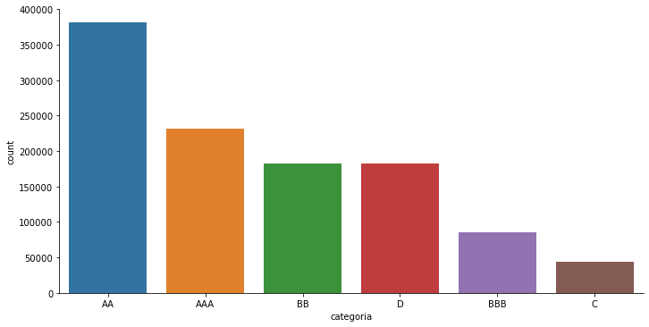

```python
sns.catplot(x = "categoria", data = df,
            kind="count",
            aspect=2,
            order = categorias.index)
```

### 1.1 Observações:

**Características identificadores:** id_animal, estabelecimento_identificador e identificador_lote, desta forma podem ser retiradas.

## 2. Visualizando principais valores estatísticos

```python
df.describe().T
```

|  | count | mean | std | min | 25% | 50% | 75% | max |
| --- | --- | --- | --- | --- | --- | --- | --- | --- |
| id_animal | 1107689.0 | 553845.000000 | 319762.415500 | 1.0000 | 276923.0000 | 553845.0000 | 830767.0000 | 1.107689e+06 |
| estabelecimento_identificador | 1107689.0 | 3930.542337 | 2078.800073 | 1.0000 | 1712.0000 | 4412.0000 | 5351.0000 | 8.385000e+03 |
| identificador_lote | 1107689.0 | 48450.900951 | 23141.412472 | 2.0000 | 25602.0000 | 51291.0000 | 69966.0000 | 8.530800e+04 |
| peso | 1107689.0 | 267.845487 | 46.498924 | 102.0000 | 236.0000 | 271.5000 | 299.0000 | 1.566000e+03 |
| classificacao_estabel | 1057853.0 | 24.481530 | 3.617385 | 21.0000 | 21.0000 | 26.0000 | 26.0000 | 3.000000e+01 |
| tot7d_chuva | 1040621.0 | 22.017195 | 30.156669 | 0.0000 | 0.7000 | 9.8000 | 32.9000 | 6.622000e+02 |
| med7d_tempinst | 1052429.0 | 24.178766 | 2.400317 | 13.1900 | 22.8300 | 24.2500 | 25.6700 | 3.507000e+01 |
| med7d_tempmax | 1051745.0 | 30.930234 | 2.558604 | 0.0000 | 29.3800 | 30.9900 | 32.5400 | 3.900000e+01 |
| med7d_tempmin | 1051745.0 | 19.002492 | 2.848329 | 0.0000 | 17.2900 | 19.2600 | 20.9200 | 3.277000e+01 |
| med7d_umidinst | 1052404.0 | 68.059538 | 9.648696 | 0.0000 | 62.5400 | 69.2000 | 74.7100 | 9.671000e+01 |
| med7d_umidmax | 1052313.0 | 87.785889 | 8.232662 | 7.6700 | 84.0000 | 89.5000 | 93.5000 | 1.000000e+02 |
| med7d_umidmin | 1051552.0 | 42.786013 | 10.288760 | 10.0000 | 36.3800 | 42.8800 | 49.5000 | 8.357000e+01 |
| med7d_velventomax | 1053066.0 | 14.620956 | 4.273704 | 0.0000 | 11.5200 | 14.4500 | 17.6900 | 2.754000e+01 |
| med7d_formituinst | 1051796.0 | 72.251367 | 3.561567 | 52.0900 | 70.1900 | 72.4400 | 74.6400 | 8.329000e+01 |
| med7d_formitumax | 1051705.0 | 85.536422 | 4.463308 | 33.3700 | 82.7900 | 85.5000 | 88.6200 | 1.007200e+02 |
| med7d_num_pixels | 1028063.0 | 26664.735085 | 29524.830255 | 151.0000 | 6365.0000 | 13526.0000 | 32960.0000 | 1.065410e+05 |
| med7d_ndvi | 1028063.0 | 0.546017 | 0.100403 | 0.2900 | 0.4600 | 0.5700 | 0.6200 | 7.400000e-01 |
| med7d_evi | 1028063.0 | 0.347147 | 0.086751 | 0.1600 | 0.2700 | 0.3700 | 0.4100 | 5.700000e-01 |
| med7d_prer_soja | 1067529.0 | 81.164669 | 8.370125 | 64.4700 | 72.8700 | 82.6400 | 88.0000 | 9.643000e+01 |
| med7d_prer_milho | 1067529.0 | 35.618083 | 4.822892 | 25.3800 | 31.9400 | 36.7000 | 39.6300 | 4.513000e+01 |
| med7d_prer_boi | 1067529.0 | 143.286837 | 5.604321 | 123.7100 | 140.3200 | 144.3100 | 146.7800 | 1.523500e+02 |
| tot1m_chuva | 1105326.0 | 97.327771 | 78.905418 | 0.0000 | 36.9700 | 75.3100 | 147.6000 | 5.006900e+02 |
| med1m_tempinst | 1107689.0 | 24.112713 | 1.806495 | 17.6000 | 22.9500 | 24.1900 | 25.4100 | 3.119000e+01 |
| med1m_tempmax | 1107689.0 | 30.900665 | 1.953843 | 10.8200 | 29.6800 | 30.8000 | 32.2400 | 3.658000e+01 |
| med1m_tempmin | 1107689.0 | 18.911530 | 2.223172 | 7.0000 | 17.4100 | 19.1700 | 20.4700 | 2.613000e+01 |
| med1m_umidinst | 1107689.0 | 67.918155 | 7.113823 | 23.3500 | 63.9000 | 68.5900 | 72.9500 | 8.535000e+01 |
| med1m_umidmax | 1107689.0 | 87.733792 | 6.504725 | 19.0900 | 84.1700 | 88.5500 | 92.6000 | 1.000000e+02 |
| med1m_umidmin | 1107689.0 | 42.510780 | 7.390655 | 18.6700 | 37.7100 | 42.5600 | 47.4500 | 7.244000e+01 |
| med1m_velventomax | 1107689.0 | 14.641720 | 3.721689 | 3.1000 | 11.7400 | 14.4500 | 17.5100 | 2.451000e+01 |
| med1m_formituinst | 1107689.0 | 72.138647 | 2.765632 | 62.2300 | 70.2900 | 72.4400 | 74.1700 | 8.100000e+01 |

[output cut: 67 more lines]

### 2.1 Possíveis outliers

#### 2.1.1 Dados de precipitações - Total de chuvas - 7 dias

```python
def plotarBoxplot (titulo,x, dataset):
    sns.set_palette('Accent')
    sns.set_style('darkgrid')
    box_plot = sns.boxplot(x= x, data = dataset, orient = 'h')
    box_plot.figure.set_size_inches(18,8)
    box_plot.set_title(titulo, fontsize = 20)
    box_plot
```

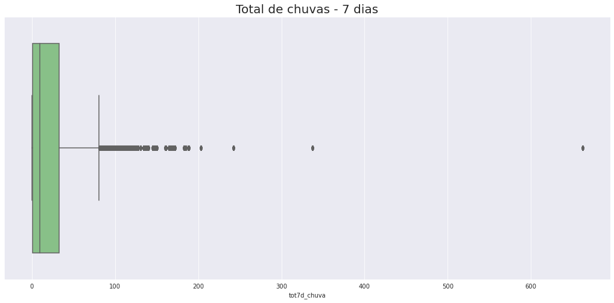

```python
plotarBoxplot ('Total de chuvas - 7 dias', 'tot7d_chuva', df )
```

Quantidade de registros a acima do limite máximo:

```python
len(df.query('tot7d_chuva > 81.18'))
```

```
49152
```

Quantidade de registros a acima de 600:

```python
len(df.query('tot7d_chuva > 600'))
```

```
129
```

Todos registro com valor maior que 600 correspondem a mesma data de abate:

```python
#Seleção dos dados considerados outliers
df_outlier_preceptacao =  df.query('tot7d_chuva > 600')
```

```python
df_outlier_preceptacao.data_abate.value_counts()
```

```
08JAN2019    129
Name: data_abate, dtype: int64
```

#### Dados de precipitações - Total de chuvas - média de 7 dias à 12meses

```python
def plotarBoxplotAgrupado (titulo, xlabel, dataset):
    sns.set_palette('Accent')
    sns.set_style('darkgrid')
    box_plot = sns.boxplot(x="variable", y="value", data=pd.melt(dataset))
    box_plot.set_xlabel(xlabel, fontsize=14)
    box_plot.figure.set_size_inches(20,15)
    box_plot.set_title(titulo, fontsize = 20)
    box_plot
```

```python
df_chuva = pd.DataFrame(data = df, columns = ['tot7d_chuva','tot1m_chuva','tot3m_chuva', 'tot6m_chuva', 'tot12m_chuva'])
```

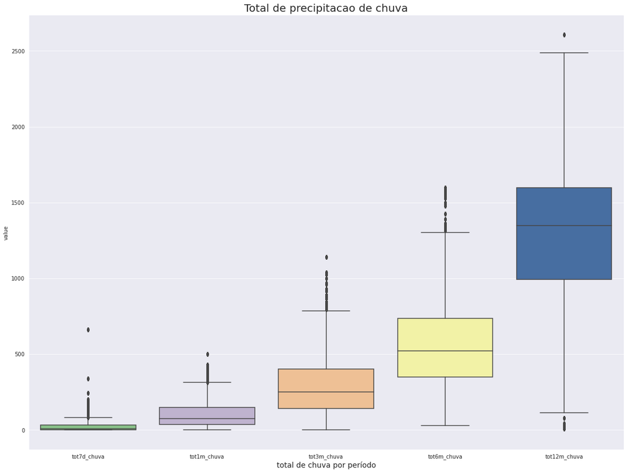

```python
plotarBoxplotAgrupado ('Total de precipitacao de chuva','total de chuva por período', df_chuva )
```

#### 2.1.2 Temperatura Mínima

```python
df_tempmin = pd.DataFrame(data = df, columns = ['med7d_tempmin','med1m_tempmin','med3m_tempmin', 'med6m_tempmin', 'med12m_tempmin'])
```

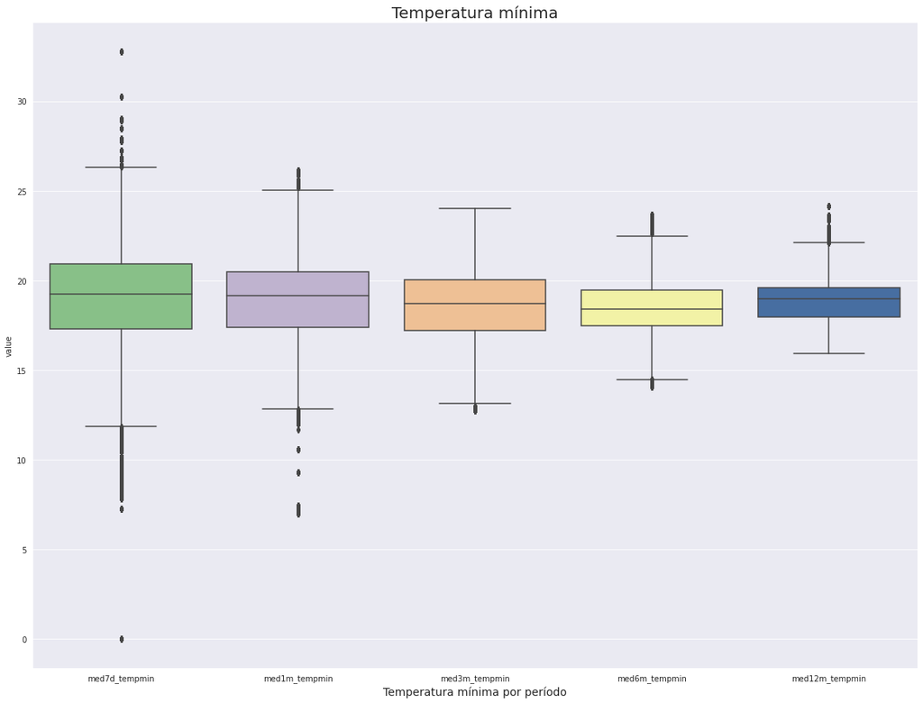

```python
plotarBoxplotAgrupado ('Temperatura mínima','Temperatura mínima por período', df_tempmin )
```

#### 2.1.3 Umidade instantânea

```python
df_umidinst = pd.DataFrame(data = df, columns = ['med7d_umidinst','med1m_umidinst','med3m_umidinst', 'med6m_umidinst', 'med12m_umidinst'])
```

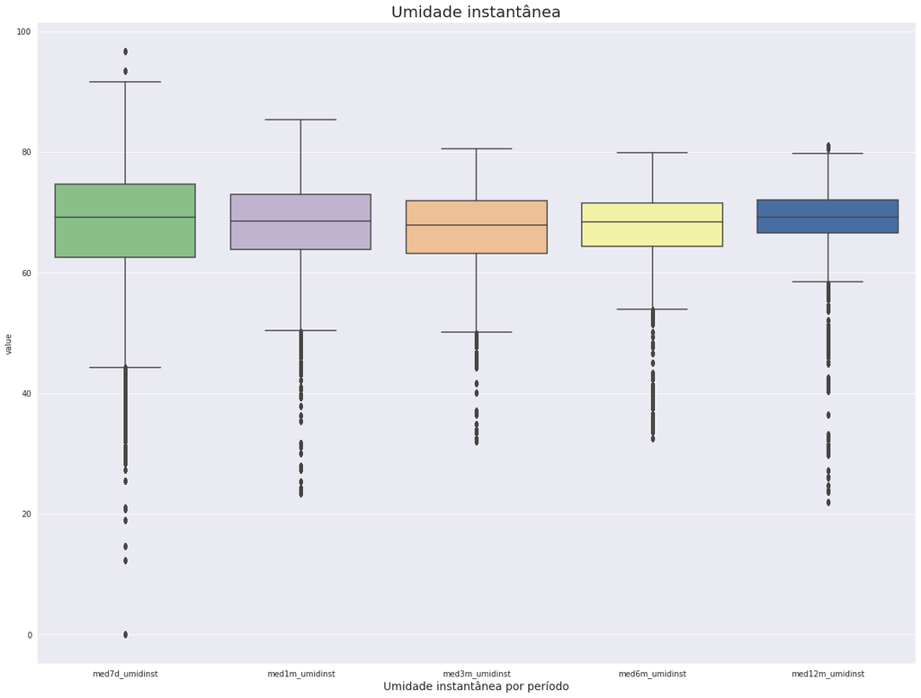

```python
plotarBoxplotAgrupado ('Umidade instantânea','Umidade instantânea por período', df_umidinst )
```

#### 2.1.4 Preço do Boi

```python
df_pre_boi = pd.DataFrame(data = df, columns = ['med7d_prer_boi','med1m_prer_boi','med3m_prer_boi', 'med6m_prer_boi', 'med12m_prer_boi'])
```

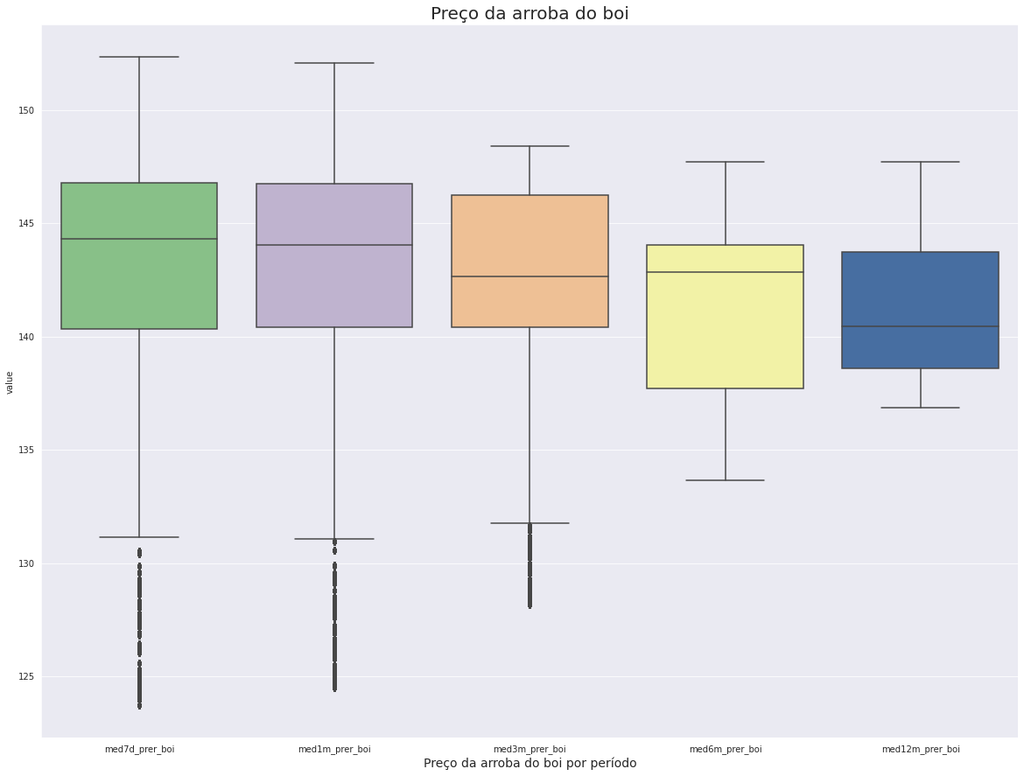

```python
plotarBoxplotAgrupado ('Preço da arroba do boi','Preço da arroba do boi por período', df_pre_boi )
```

#### 2.1.5 Dados de Peso da carcaça

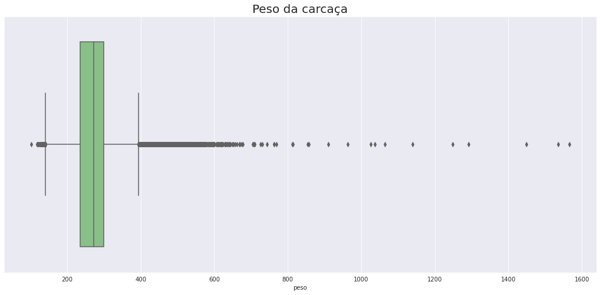

```python
plotarBoxplot ('Peso da carcaça', 'peso', df )
```

```python
def limitesBoxplot (caracteristica):
    Q1 = df[caracteristica].quantile(0.25)
    Q3 = df[caracteristica].quantile(0.75)
    IQR = Q3 - Q1
    LS = Q3 + ( 1.5 * IQR)
    LI = Q1 - ( 1.5 * IQR)
    print('Limite Infeiror: ',LI,' Limite Superior: ',LS)
```

```python
limitesBoxplot ('peso')
```

```
Limite Infeiror:  141.5  Limite Superior:  393.5
```

### 2.1.6 Observações:

Foram encontrados valores discrepantes para as características acima, conforme apresentado nos respectivos gráficos Boxplot. Precisamos saber se condizem com a realidade ou serão considerados outliers.

### 2.2 Valores repetidos: Dados do múmero de pixels

```python
df_num_pixels = pd.DataFrame(data = df, columns = ['med7d_num_pixels','med1m_num_pixels','med3m_num_pixels', 'med6m_num_pixels', 'med12m_num_pixels'])
```

```python
df_num_pixels.describe().T
```

|  | count | mean | std | min | 25% | 50% | 75% | max |
| --- | --- | --- | --- | --- | --- | --- | --- | --- |
| med7d_num_pixels | 1028063.0 | 26664.735085 | 29524.830255 | 151.0 | 6365.0 | 13526.0 | 32960.0 | 106541.0 |
| med1m_num_pixels | 1067309.0 | 26634.541413 | 29483.129345 | 151.0 | 6365.0 | 13526.0 | 32960.0 | 106541.0 |
| med3m_num_pixels | 1067309.0 | 26634.541413 | 29483.129345 | 151.0 | 6365.0 | 13526.0 | 32960.0 | 106541.0 |
| med6m_num_pixels | 1067309.0 | 26634.541413 | 29483.129345 | 151.0 | 6365.0 | 13526.0 | 32960.0 | 106541.0 |
| med12m_num_pixels | 1062416.0 | 26737.740254 | 29511.611682 | 151.0 | 6365.0 | 13526.0 | 32960.0 | 106541.0 |

### 2.2.1 Observações:

**Valores repetidos:** As características med7d_num_pixels, med1m_num_pixels, med3m_num_pixels, med6m_num_pixels e med12m_num_pixels possuem os mesmo valores, podemos manter uma característica.

## 3. Dados ausentes

Calcular a porcentagem de valores ausentes.

```python
round(df.isnull().mean() * 100,2).sort_values(ascending=False)
```

```
qual_alianca                        67.76
lista_trace                         53.96
erosao_laminar_ou_em_sulco_igua     22.05
boa_cobertura_vegetal_com_baixa     22.05
med7d_evi                            7.19
med7d_ndvi                           7.19
med7d_num_pixels                     7.19
tot7d_chuva                          6.05
med7d_umidmin                        5.07
med7d_tempmax                        5.05
med7d_tempmin                        5.05
cnt7d_cl_ituinst                     5.05
med7d_formituinst                    5.05
cnt7d_cl_itumax                      5.05
med7d_formitumax                     5.05
med7d_umidmax                        5.00
med7d_umidinst                       4.99
med7d_tempinst                       4.99
med7d_velventomax                    4.93
regua_de_manejo                      4.50
bpa                                  4.50
participa_de_aliancas_mercadolog     4.50
classificacao_estabel                4.50
identificacao_individual             4.50
fabrica_racao                        4.50
rastreamento_sisbov                  4.50
possui_outros_ incentivo             4.50
pratica_recuperacao_pastagem         4.50
med12m_num_pixels                    4.09
med12m_evi                           4.09
med12m_ndvi                          4.09
med1m_evi                            3.65
med1m_ndvi                           3.65
med6m_ndvi                           3.65
med6m_evi                            3.65
med3m_num_pixels                     3.65
med3m_evi                            3.65
med3m_ndvi                           3.65
med1m_num_pixels                     3.65
med6m_num_pixels                     3.65
```

[output cut: 71 more lines]

```
med3m_umidmin                        0.00
med3m_umidmax                        0.00
med3m_umidinst                       0.00
med3m_tempmax                        0.00
med1m_umidmin                        0.00
med3m_tempinst                       0.00
tot3m_chuva                          0.00
med1m_prer_boi                       0.00
estabelecimento_municipio            0.00
med1m_prer_soja                      0.00
med1m_formitumax                     0.00
med1m_formituinst                    0.00
med1m_velventomax                    0.00
classificacao                        0.00
dtype: float64
```

Calcular a quantidade de valores ausentes.

```python
df.isnull().sum().sort_values(ascending=False)
```

```
qual_alianca                        750604
lista_trace                         597720
erosao_laminar_ou_em_sulco_igua     244259
boa_cobertura_vegetal_com_baixa     244259
med7d_evi                            79626
med7d_ndvi                           79626
med7d_num_pixels                     79626
tot7d_chuva                          67068
med7d_umidmin                        56137
cnt7d_cl_itumax                      55984
med7d_formitumax                     55984
med7d_tempmax                        55944
med7d_tempmin                        55944
med7d_formituinst                    55893
cnt7d_cl_ituinst                     55893
med7d_umidmax                        55376
med7d_umidinst                       55285
med7d_tempinst                       55260
med7d_velventomax                    54623
possui_outros_ incentivo             49836
rastreamento_sisbov                  49836
classificacao_estabel                49836
bpa                                  49836
regua_de_manejo                      49836
identificacao_individual             49836
fabrica_racao                        49836
pratica_recuperacao_pastagem         49836
participa_de_aliancas_mercadolog     49836
med12m_num_pixels                    45273
med12m_evi                           45273
med12m_ndvi                          45273
med1m_evi                            40380
med1m_ndvi                           40380
med6m_ndvi                           40380
med6m_evi                            40380
med3m_num_pixels                     40380
med3m_evi                            40380
med3m_ndvi                           40380
med1m_num_pixels                     40380
med6m_num_pixels                     40380
```

[output cut: 71 more lines]

```
med3m_umidmin                            0
med3m_umidmax                            0
med3m_umidinst                           0
med3m_tempmax                            0
med1m_umidmin                            0
med3m_tempinst                           0
tot3m_chuva                              0
med1m_prer_boi                           0
estabelecimento_municipio                0
med1m_prer_soja                          0
med1m_formitumax                         0
med1m_formituinst                        0
med1m_velventomax                        0
classificacao                            0
dtype: int64
```

### 3.1 Observações

É necessário o suporte técnico do especialista para nos dizer a relevância dessas características dentro da análise, ou se podemos imputar algum valor.

## 4. Matriz de correlação

```python
selecao_mes = ['estabelecimento_municipio', 'data_abate',
       'tipificacao', 'maturidade', 'acabamento', 'peso',
       'motivo_desclassificacao', 'q_classificacao_estabel',
       'q_outros_incentiv', 'q_pratica_recuperacao_pa',
       'q_fertiirrigacao', 'q_ilp', 'q_ilpf', 'q_ifp', 'q_fabrica_racao',
       'q_identificacao_individual', 'q_regua_manejo', 'q_bpa',
       'q_aliancas_mercadolog', 'q_qual_alianca',
       'q_cobertura_vegetal_80_area', 'q_erosaoo_sulco_20_area',
       'q_sisbov', 'q_lista_trace', 'data12m', 'data6m', 'data3m',
       'data1m', 'data7d', 'tot7d_chuva', 'med7d_tempinst',
       'med7d_tempmax', 'med7d_tempmin', 'med7d_umidinst',
       'med7d_umidmax', 'med7d_umidmin', 'med7d_velventomax',
       'med7d_formituinst', 'med7d_formitumax', 'med7d_num_pixels',
       'med7d_ndvi', 'med7d_evi', 'med7d_prer_soja', 'med7d_prer_milho',
       'med7d_prer_boi', 'cnt7d_cl_itumax', 'cnt7d_cl_ituinst', 'ano', 'categoria', 'classificacao']
```

```python
df_matriz = pd.read_csv('../../dados/dadosCompletos.csv', encoding='ISO-8859-1', sep=';', usecols=selecao_mes)
```

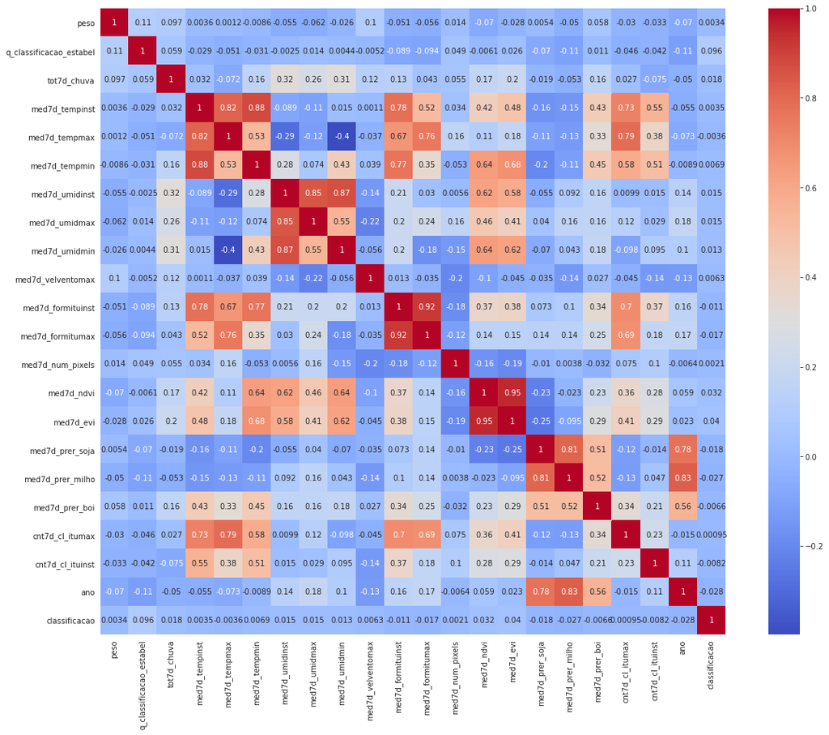

```python
plt.figure(figsize=(20,15))
sns_plot = sns.heatmap(data=df_matriz.corr(),annot=True,cmap='coolwarm', square=True);
fig = sns_plot.get_figure()
fig.savefig("Matriz_Corr_resumido.png")
```

### Caracaterísticas com alta correlação:

| Caracterísica 1 | Caracterísica 2 | Correlação |
| --- | --- | --- |
| Temperatura instantânea (tempinst) | Temperatura máxima (tempmax) | 0,82 |
| Temperatura instantânea (tempinst) | Temperatura mínima (tempmin) | 0,88 |
| Temperatura instantânea (tempinst) | Fómrula, índice de temperatura e umidade instantanea (formituint) | 0,78 |
| Temperatura instantânea (tempinst) | Classe na qual o ITU maximo se encontra (cl_itumax) | 0,73 |
| Temperatura máxima (tempmax) | Fórmula, índice de temperatura e umidade maxima (formintumax) | 0,76 |
| Temperatura máxima (tempmax) | Classe na qual o ITU máximo se encontra (cl_itumax) | 0,79 |
| Temperatura mínima (tempmin) | Fórmula, índice de temperatura e umidade instantânea (formituinst) | 0,77 |
| Umidade instantânea do ar (umidinst) | Umidade máxima (umidmax) | 0,85 |
| Umidade instantânea do ar (umidinst) | Umidade mínima do ar (umidmin) | 0,87 |
| Fórmula, índice de temperatura e umidade instantânea (formituinst) | Fórmula, índice de temperatura e umidade maxima (fomitumax) | 0,92 |
| Fórmula, índice de temperatura e umidade máxima (formituinst) | Classe na qual o ITU máximo se encontra (cl_itumax) | 0,7 |
| Índice de Vegetação da Diferença Normalizada (ndvi) | Índice de Vegetação Melhorado (evi) | 0,95 |
| Preço da Soja (prer_soja) | Preço do milho (prer_milho) | 0,81 |
| Classe na qual o ITU máximo (cl_itumax) | Fórmula, índice de temperatura e umidade máxima (formitumax) | 0,69 |

### 4.1 Observações

Algumas características poussem um algo grau de correlação, podemos considera-las reundantes e manter apenas uma delas.

```python
names = df.columns[8:len(df)].tolist()
df.fillna(df.mean(), inplace=True)
array = df.values
X = array[:,8:len(df)]
```